# Visualización de datos con ggplot2

## ¿Qué es ggplot2?

**ggplot2** es un paquete para la creación de datos en R. Se considera parte del [tidyverse](https://www.tidyverse.org/) (al igual que dplyr) y es uno de los más usados por la calidad de los gráficos que produce y la facilidad de su uso.

Para producir gráficos con ggplot, solo necesitamos entregarle la data que queremos graficar, indicarle las variables a incluir, y algunos otros datos referidos a los título y leyendas.

En la sesión de hoy veremos los siguientes gráficos:

- Gráfico de barras (barplot)
- Gráfico de líneas (linechart)
- Grafico de torta (piechart)

## Como usar ggplot

Para usar ggplot, lo primero que necesitamos es tenerlo instalado entre nuestros parquetes de R. Para eso, ejecutamos el siguiente comando en nuestra consola:

```r
install.packages("ggplot2")
```

Una vez instalado, para usarlo en nuestro archivo R o Rmd, solo debemos cargralo al inicio de nuestros guiones:

```r
# Librerías
# ...
library(ggplot2)
```

## Componentes de ggplot2

ggplot2 está basado en una “gramática de gráficos”. Es decir, que parten de la premisa de que todo gráfico se puede crear a partir de tres componentes:

- Un conjunto de datos o *data set*.
- Un sistema de coordenadas.
- **Geoms** o marcas visuales que representan los puntos de datos a visualizar.

Adicionalmente también se incluye el componente estético (aesthetic, aes) para definir los colores y formas a usar en el gráfico.

## Gráfico de barra

## Gráfico simple

El gráfico de barras es el más simple que podemos hacer en ggplot2. Empecemos con un ejemplo:

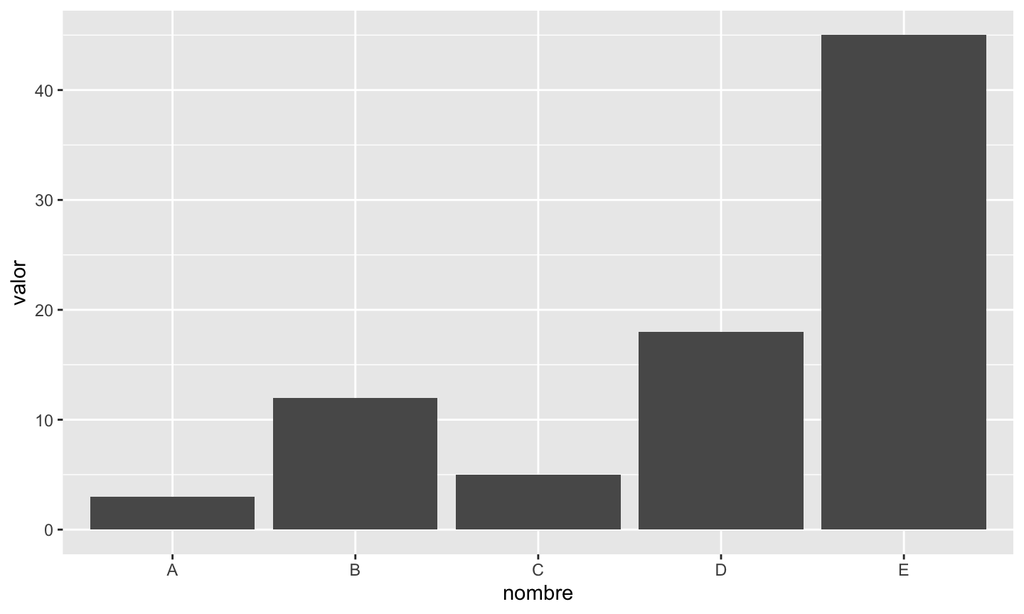

```r
# Creamos una data para simular
data_barras <- data.frame(
    nombre = c("A", "B", "C", "D", "E"),
    valor = c(3, 12, 5, 18, 45)
)

# Gráfico de barras
ggplot(data_barras, aes(x = nombre, y = valor)) +
    geom_bar(stat = "identity")
```

## Agregando colores

Podemos darle más vida al gráfico agregando colores

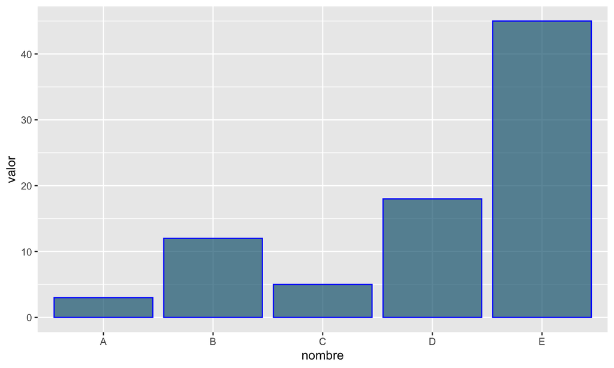

```r
ggplot(data_barras, aes(x = nombre, y = valor)) +
    geom_bar(
        stat = "identity",
        color = "blue", # Algunos colores básicos se pueden llamar por nombre
        fill = rgb(0.1, 0.4, 0.5, 0.7) # Para otros colores usamos su código
    )
```

## Usando paletas

También podemos obtener los colores con paletas prediseñadas. En este caso, es importante indicar dentro de las opciones de estética, sobre que variable vamos a aplicar los colores (en este caso `nombre`)

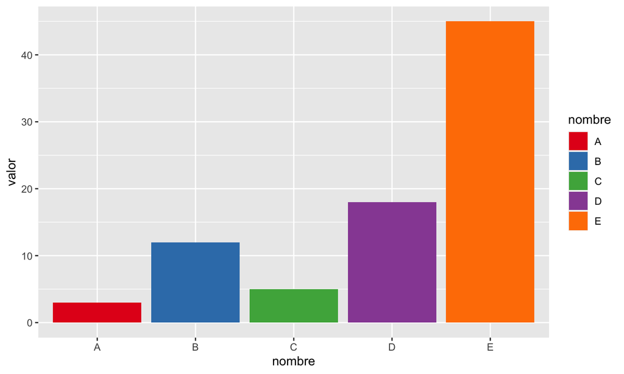

```r
ggplot(data_barras, aes(x = nombre, y = valor, fill = nombre)) +
    geom_bar(stat = "identity") +
    scale_fill_brewer(palette = "Set1")
```

## Grafico rotado

Podemos rotar nuestro gráfico usando el comando `coord_flip()` al final.

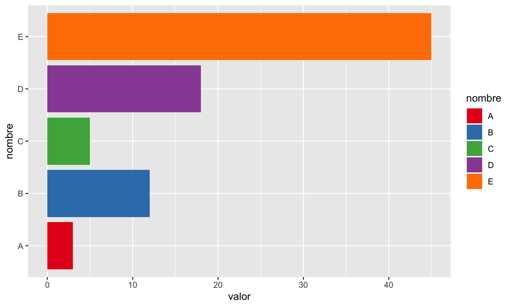

```r
ggplot(data_barras, aes(x = nombre, y = valor, fill = nombre)) +
    geom_bar(stat = "identity") +
    scale_fill_brewer(palette = "Set1") +
    coord_flip()
```

## Títulos y nombres de ejes

La función labs nos permite indicar que nombres queremos en nuestros gráficos

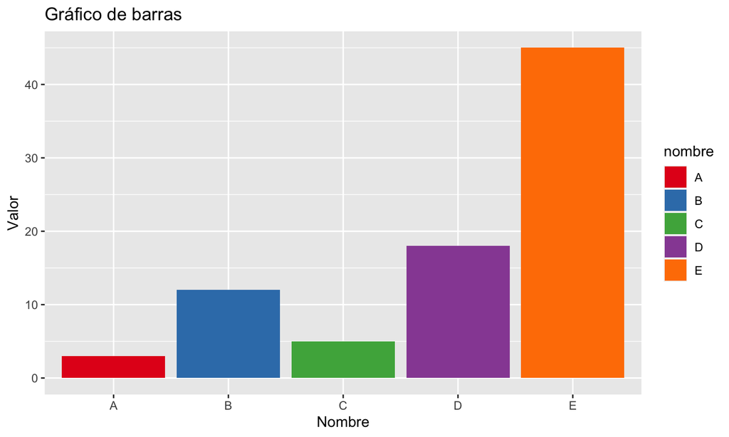

```r
ggplot(data_barras, aes(x = nombre, y = valor, fill = nombre)) +
    geom_bar(stat = "identity") +
    scale_fill_brewer(palette = "Set1") +
    labs(
        title = "Gráfico de barras",
        x = "Nombre",
        y = "Valor"
    )
```

## Gráfico de línea

## Gráfico simple

```r
# Creamos data aleatoria
valores_x <- 1:10
valores_y <- cumsum(rnorm(10))
data_linea <- data.frame(valores_x, valores_y)
```

Creamos el gráfico usamo `geom_line()`

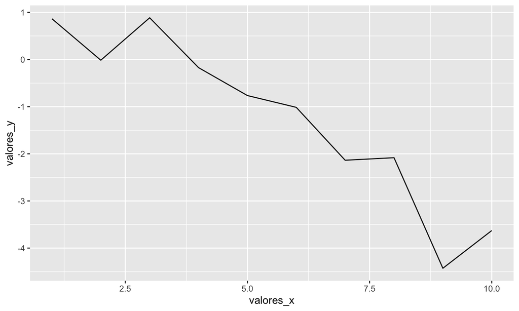

```r
ggplot(data_linea, aes(x = valores_x, y = valores_y)) +
    geom_line()
```

## Colores

Podemos personalizar el gráfico indicando opciones en `geom_line()`

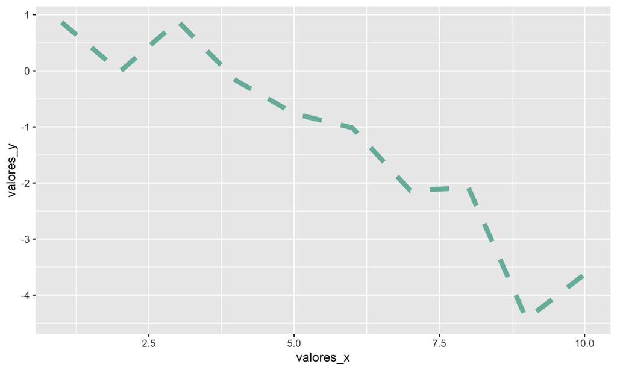

```r
ggplot(data_linea, aes(x = valores_x, y = valores_y)) +
    geom_line(
        color = "#69b3a2",
        linewidth = 2, # ancho de línea
        alpha = 0.9, # transparencia de linea
        linetype = 2 # tipo de línea
    )
```

## Gráfico de torta

## Gráfico simple

A diferencia de los otros dos tipos de gráficos, no tenemos una función directa en ggplot2 para crear un gráfico de torta. Sin embargo, podemos modificar un gráfico de barras con la función `coord_polar()` para crear uno.

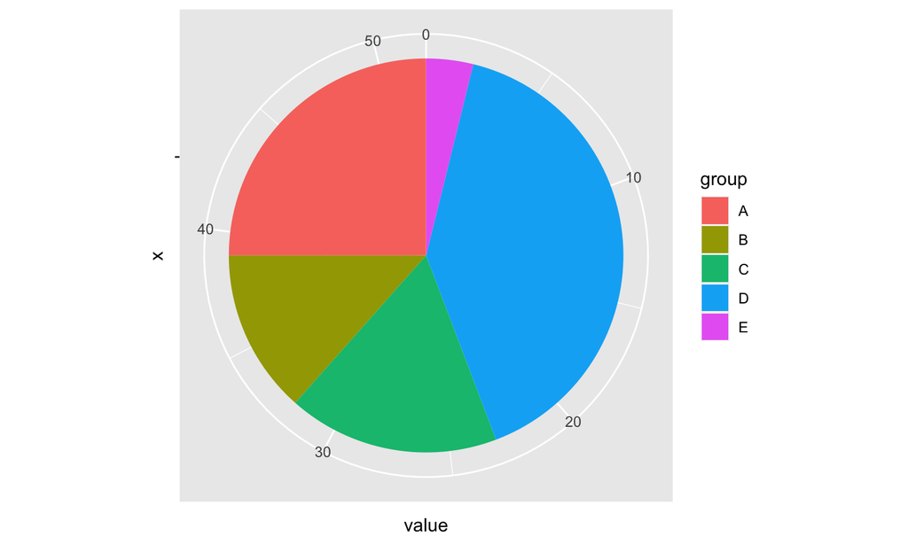

```r
# Creamos data de ejemplo
data_torta <- data.frame(
    group = LETTERS[1:5],
    value = c(13, 7, 9, 21, 2)
)

# Basic piechart
ggplot(data_torta, aes(x = "", y = value, fill = group)) +
    geom_bar(stat = "identity", width = 1) +
    coord_polar("y", start = 0)
```

## Eliminado información superflua

Agregando la función `theme_void()` eliminamos la información que no necesitamos. Existen otros “temas” o plantillas que podemos usar como báse de nuestros gráficos.

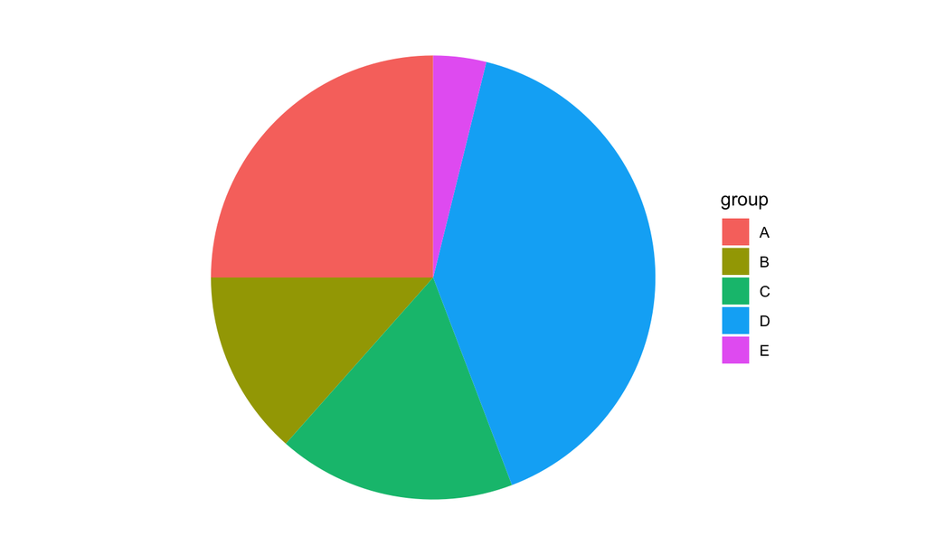

```r
ggplot(data_torta, aes(x = "", y = value, fill = group)) +
    geom_bar(stat = "identity", width = 1) +
    coord_polar("y", start = 0) +
    theme_void()
```

## Ejercicio

Con una data que ustedes creen en excel o descargada de internet, creen cada uno de los gráficos de la sesión de hoy. Todos deben incluir títulos y nombres para los ejes (cuando corresponda); asi como usar diferentes colores para distinguir entre los datos.

Pueden usar los siguientes recursos como ayuda:

- [R-graph-galery](https://r-graph-gallery.com/): Galería de gráficos de R que incluye instrucciones para crearlos y personalizarlos.
- Ayuda memoría [Visualización de datos con ggplot2](https://raw.githubusercontent.com/rstudio/cheatsheets/main/translations/spanish/data-visualization_es.pdf): PDF guía para el uso de ggplot2